# Expection of Genetic Variance in Bi-Parental Population

## Introduction

The expectation of genetic variance in a bi-parental population can be derived using genome-wide marker effects. This would avoid the use of simulated populations in order to determine the genetic variance.

Assuming dominance and epistasis are absent, the genetic variance at a single for a recombinant inbred population is

$$V_G = 2V_A = 2 (2pqa^2)$$

and the expected value of $q$ is $E(q) = 1 - E(p)$

Consider two marker loci, $i$ and $j$ that are separated by recombination distance $r$. The marker effects are estimated as $a_i = 1$ and $a_j = 2$. One individual is homozygous for the first allele at marker $i$ and homozygous for the first allele at marker $j$. The other individual is homozygous for the second allele at marker $i$ and homozygous for the second allele at marker $j$.

If the recombination rate $r$ is 0.5, the genetic variance in the bi-parental population resulting from the cross of those two individuals is

Let us test this using R/qtl

```r
library(qtl)

# Create a map
map <- sim.map(len = c(100, 100), n.mar = 3, include.x = F, eq.spacing = T)

# Identify the markers
mar_i <- "D1M2"
mar_j <- "D2M2"

# Simulate a RIL population
model <- rbind(c(1, 50, 1, 0),
               c(2, 50, 2, 0))

# Create founders
founders <- rbind(c(1, 1),
                  c(-1, -1))

varG <- replicate(n = 100, expr = {

  pop <- sim.cross(map = map, model = model, type = "riself", n.ind = 200, error.prob = 0, missing.prob = 0,
                   map.function = "haldane", keep.qtlgeno = T)

  # Extract qtl genotypes
  pop_qtl_geno <- do.call("cbind", lapply(X = pop$geno, FUN = function(chr) chr$data[,2]))

  # Iterate over qtl
  for (i in seq(ncol(pop_qtl_geno))) {
    locus <- pop_qtl_geno[,i]
    pop_qtl_geno[,i] <- ifelse(locus == 1, founders[1,i], founders[2,i])
  }

  # Calculate genotypic values
  pop_gen_val <- pop_qtl_geno %*% model[,3]

  # Return the genetic variance
  var(pop_gen_val) })

# Mean and sd
c(mu = mean(varG))
```

```
##       mu
## 5.012606
```

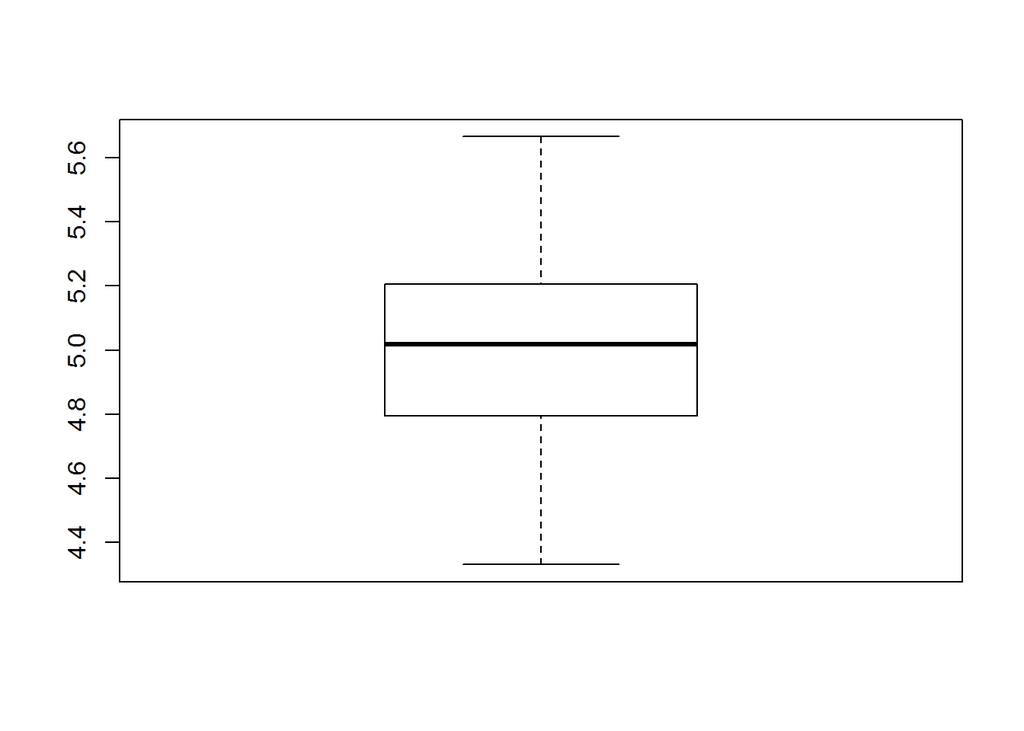

```r
boxplot(varG)
```